# Twitter Analytics Using R

Dr. Qiusheng Wu

The tutorial will work through practical examples showing you how to extract and visualize Twitter data using R.

## Part 1. Extracting Tweets

### Prerequisites

1. You have already installed [R](http://www.r-project.org/) and are using [RStudio](https://www.rstudio.com/products/rstudio/download/).
2. In order to extract tweets, you will need a Twitter application and hence a Twitter account. If you don’t have a Twitter account, please [sign up](https://twitter.com/signup).
3. Use your Twitter login ID and password to sign in at [Twitter Developers](https://apps.twitter.com/).

### Create a Twitter Application

1. Navigate to [Twitter Developers](https://apps.twitter.com/). Click the button **Create New App** in the upper right corner.

[figure not shown]

2. Fill in the required application details, including **Name**, **Description**, and **Website**. Note that the **Name** must be unique. If your chosen name has been taken, try a new one. Click the button **Create your Twitter application** in the lower-left corner.

[figure not shown]

3. Click the **Keys and Access Tokens** tab under your created Twitter Application. Then click the button **Create my access token** in the lower-left corner

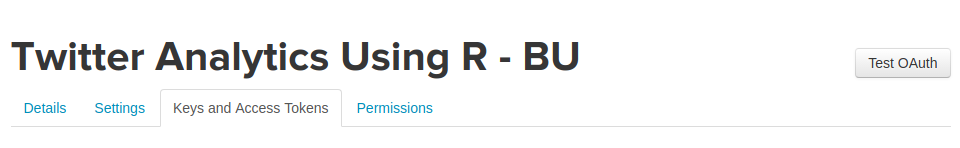

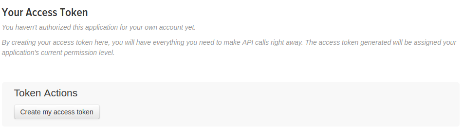

4. Note the values of **Consumer Key (API Key)**, **Consumer Secret (API Secret)**, **Access Token**, and **Access Token Secret** handy for future use. You should keep these secret. If anyone was to get these keys, they could effectively access your Twitter account.

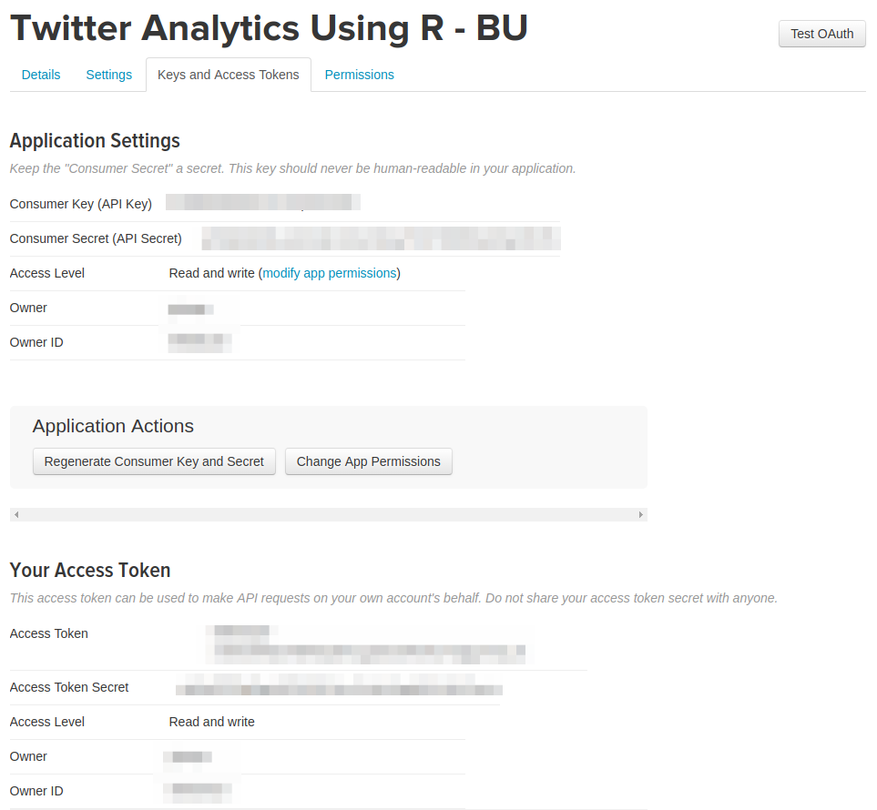

### Install and Load R Packages

For the purpose of this tutorial, we will need the following packages:

- **ROAuth**: Provides an interface to the OAuth 1.0 specification, allowing users to authenticate via OAuth to the server of their choice.
- **TwitteR**: Provides an interface to the Twitter web API.

```r
if (!require(twitteR)) {install.packages("twitteR")}
if (!require(ROAuth)) {install.packages("ROAuth")}
library(twitteR)
library(ROAuth)
```

### Authentication with OAuth

Authorize App to use your account, i.e., established handshake between Twitter and R.

```r
# you must get the following information from the Twitter App you just created
my.consumer.key = "fH4IijcQUrwxEQ3mmb6G2gzUc"
my.consumer.secret = "FxkuV6ePyFaia2LmyxetoH50IxGrQcEYbwnLe3EjVDWsCdPrhJ"
my.access.token = "99989439-wG82y2hMmAmlJ1iIlQgNu0l65ZOKVuVscj4Idm9Xu"
my.access.token.secret = "QNehvUZOGNNZyqFYDCAP6tlWEHWIBbKIhiqPEKAM2SOoT"
my_oauth <- setup_twitter_oauth(consumer_key = my.consumer.key, consumer_secret = my.consumer.secret, access_token = my.access.token, access_secret = my.access.token.secret)
```

```
[1] "Using direct authentication"
```

```r
save(my_oauth, file = "my_oauth.Rdata")
```

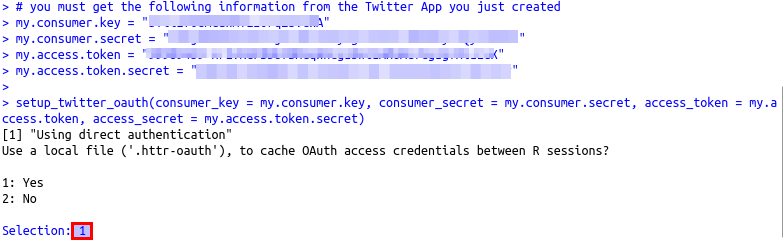

### Extract Tweets Using a Search Term

```r
search.string <- "#HurricaneNate"
result.term <- searchTwitter(search.string, n = 100)
head(result.term)
```

```
[[1]]
[1] "mdorsey92: RT @jacobdickeywx: The eyewall approaches #HURRICANENATE #NATE #GULFPORT https://t.co/uFaobimvjY"

[[2]]
[1] "Mi_Puerto_Rico: RT @Readygov: Before heading to bed make sure you have different ways to receive emergency alerts throughout the night. #HurricaneNate http…"

[[3]]
[1] "SVH2: RT @FoxNews: .@AdamKlotzFNC on #HurricaneNate: \"Currently you're looking at 90 mph winds, that's a Category 1 storm.\" https://t.co/RnTJDFp7…"

[[4]]
[1] "YusefforPeace: RT @MeritLaw: Our volunteers at #AmericanBlackCross are preparing for #HurricaneNate. Visit https://t.co/jCrBVhYPN4 to pitch in! #ItsOnUs #…"

[[5]]
[1] "Torchbug: RT @realDonaldTrump: Our great team at @FEMA is prepared for #HurricaneNate. Everyone in LA, MS, AL, and FL please listen to your local aut…"

[[6]]
[1] "Butch2763: RT @realDonaldTrump: Our great team at @FEMA is prepared for #HurricaneNate. Everyone in LA, MS, AL, and FL please listen to your local aut…"
```

### Convert Results to Data Frame

```r
df.term <- twListToDF(result.term)
write.csv(df.term, "HurricaneNate.csv")
```

### Search Tweets Using lat/lon

```r
result.latlon <- searchTwitter('nba', geocode='29.8174,-95.6814,20mi', n = 100)
head(result.latlon)
```

```
[[1]]
[1] "ELOSSports: Maurice Evans @1MoEvans shares his personal story, #ELOSSports, and #NBA. #Entrepreneurs #Athletes #sportstech… https://t.co/TbLAUKylGk"

[[2]]
[1] "Jabari316: I added a video to a @YouTube playlist https://t.co/m07ktuDRxH NBA 2K18 iOS My Career - WE LIT - BACK WITH THE PLAYMAKER"

[[3]]
[1] "jessielantz: RT @HoustonRockets: Throughout October and November, we will honor the Heroes of Harvey that YOU nominate &amp; recognize them on-court: https:…"

[[4]]
[1] "SWHTown30: You called this man Gary Harris one of the worse defending guards in the NBA https://t.co/bwceHj9HXJ"

[[5]]
[1] "SWHTown30: Tatum is not ready for the NBA and will be hard to notice the talent right now https://t.co/PCjGjhDwje"

[[6]]
[1] "kerstindonota_9: RT @HoustonRockets: Squad is up 69-37 with 3:41 left in the first-half. \n\n\xed愼㸰戼㹤\xed戼㸳\u008a Gordon 14pts\n\xed愼㸰戼㹤\xed戼㸳\u008a Capela 12pts 9reb \n\xed愼㸰戼㹤\xed戼㸳\u008a CP3 11pts/7ast \n\nLive at ht…"
```

```r
df.latlon <- twListToDF(result.latlon)
write.csv(df.latlon, "NBA.csv")
```

### Identify Trending Topics

You can use TwitteR to identify what is currently “trending” on Twitter in a specific location by using Yahoo’s Where On Earth ID, or *woeid*. You can look at all places around the world that have a woeid by entering the following R script:

```r
availableTrendLocations()
```

| name | country | woeid |
| --- | --- | --- |
| Worldwide |  | 1 |
| Winnipeg | Canada | 2972 |
| Ottawa | Canada | 3369 |
| Quebec | Canada | 3444 |
| Montreal | Canada | 3534 |
| Toronto | Canada | 4118 |
| Edmonton | Canada | 8676 |
| Calgary | Canada | 8775 |
| Vancouver | Canada | 9807 |
| Birmingham | United Kingdom | 12723 |

[output cut: 457 more lines]

You can also find the woeid for any places near a particular latitude-longitude coordinate pair. To find the woeid for New York City, you can enter the following R script:

```r
closestTrendLocations(40.736881,-73.98887)
```

| name | country | woeid |
| --- | --- | --- |
| New York | United States | 2459115 |

Let’s use the woeid for New York to collect data on what is trending in New York.

```r
ny <- getTrends(2459115)
head(ny,n = 10)
```

|  | name | url | query | woeid |
| --- | --- | --- | --- | --- |
| 1 | #RoarWithPride | http://twitter.com/search?q=%23RoarWithPride | %23RoarWithPride | 2459115 |
| 2 | #UFC216 | http://twitter.com/search?q=%23UFC216 | %23UFC216 | 2459115 |
| 3 | Girardi | http://twitter.com/search?q=Girardi | Girardi | 2459115 |
| 4 | #IMKona | http://twitter.com/search?q=%23IMKona | %23IMKona | 2459115 |
| 5 | #NYCC | http://twitter.com/search?q=%23NYCC | %23NYCC | 2459115 |
| 6 | The Yankees | http://twitter.com/search?q=%22The+Yankees%22 | %22The+Yankees%22 | 2459115 |
| 7 | #jazz | http://twitter.com/search?q=%23jazz | %23jazz | 2459115 |
| 8 | Michigan State | http://twitter.com/search?q=%22Michigan+State%22 | %22Michigan+State%22 | 2459115 |
| 9 | Harbaugh | http://twitter.com/search?q=Harbaugh | Harbaugh | 2459115 |
| 10 | Gary Harris | http://twitter.com/search?q=%22Gary+Harris%22 | %22Gary+Harris%22 | 2459115 |

```r
write.csv(ny, "NYtrends.csv")
```